# Characrtistics Evaluation of Cypress Ck nr Westfield

Vahid Salahi

February 3, 2017

# Downloading and cleaning data

The peak annual stream-flow and daily stream-flow data for USGS 08069000 Cypress Ck nr Westfield, TX were downloaded for performing necessary analysis. R programming is used for this aim and parts of the code are presented in this report to illustrate R programming usage in stochastic approach of data analysis. All the materials (data and codes) can be found [here](https://github.com/vsalahi).

First, the answer to the following question is investigated:

- Is there a temporal trend in peak flows?

To see if there is any temporal trend for the peak flow data, the time series of annual peak stream-flow data were plotted and the regression line was obtained. The temporal peak flow data was plotted as follows:

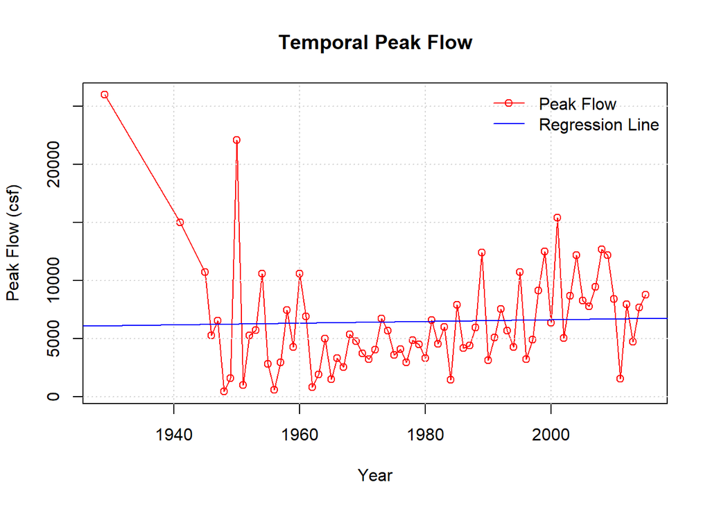

The regression line appears to have a very small slope which means there is no temporal trend in the data. The summary of the regression line shows a p-value of $0.7707$ which indicates no correlation for the time series. P-value for this regression line is presented in the last line of the summary function.

```r
# "lm" is the regression line
summary(lm)
```

```
##
## Call:
## lm(formula = peakflow ~ hydyear)
##
## Residuals:
##    Min     1Q Median     3Q    Max
##  -5840  -2902  -1023   1569  19875
##
## Coefficients:
##             Estimate Std. Error t value Pr(>|t|)
## (Intercept) -7996.21   49504.35  -0.162    0.872
## hydyear         7.32      25.02   0.293    0.771
##
## Residual standard error: 4601 on 71 degrees of freedom
## Multiple R-squared:  0.001205,   Adjusted R-squared:  -0.01286
## F-statistic: 0.08563 on 1 and 71 DF,  p-value: 0.7707
```

By looking at the data we notice that the first point of the data has very high value and after that for several years there is no data reported. Therefore, the first two points of the data have been excluded to see how the regression line looks like. Regression line is very sensitive to outliers.

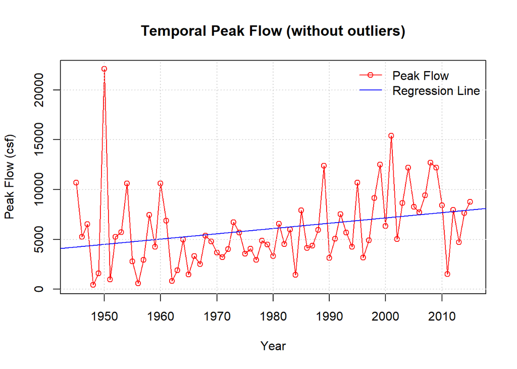

```r
summary(lm)
```

```
##
## Call:
## lm(formula = peakflow[3:73] ~ hydyear[3:73])
##
## Residuals:
##     Min      1Q  Median      3Q     Max
## -6211.3 -2265.8  -733.5  1191.3 17589.8
##
## Coefficients:
##                Estimate Std. Error t value Pr(>|t|)
## (Intercept)   -98459.34   42719.37  -2.305   0.0242 *
## hydyear[3:73]     52.80      21.57   2.448   0.0169 *
## ---
## Signif. codes:  0 '***' 0.001 '**' 0.01 '*' 0.05 '.' 0.1 ' ' 1
##
## Residual standard error: 3726 on 69 degrees of freedom
## Multiple R-squared:  0.07989,    Adjusted R-squared:  0.06655
## F-statistic: 5.991 on 1 and 69 DF,  p-value: 0.01693
```

The Mann-Kendall trend test is another tool that can be used for monotonic trend analysis in a time series. A p-value of $0.006353$ is obtained from this test which means a significant correlation in time series.

```r
MannKendall(peakflow)
```

```
## tau = 0.219, 2-sided pvalue =0.0063537
```

Based on this analysis, it can be concluded that the time series is non-stationary. This is due to a significant trend in temporal data which indicates change in statistics properties such as mean and variance. The time series has a positive trend meaning increase in peak flow data

### Empirical Cumulative Distribution Function

Assuming stationarity in the peak flow data, a cumulative distribution function was drawn assuming Gringorten Plotting position. The following piece of code shows the Gringorten function which has been applied on the data to draw the cumulative distribution function:

```r
gringorten <- function(data){
        grig <- (rank(data)-0.44)/(length(data)+0.12)
        return(grig)
}
```

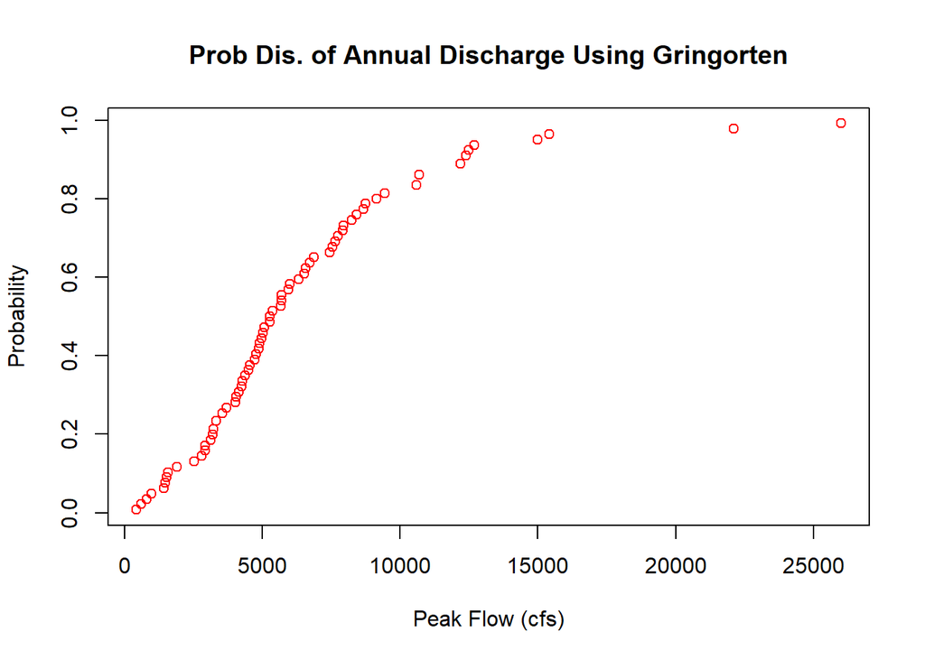

### Theoretical Cumulative Distribution Functions

Assuming stationarity, theoretical cumulative distribution functions for the annual peak flows assuming Normal, Log-normal, Gumbel and Generalized Extreme Value (GEV) distributions were developed. `fitdistr` in *fitdistrplus* package and `fevd` in *extRemes* package are the functions to fit Normal/Log_normal and Gumbel/GEV models to the peak flow data. The following graphs show the observed peak flow values versus the predicted values by Normal, Log-normal, Gumbel and GEV distribution models.

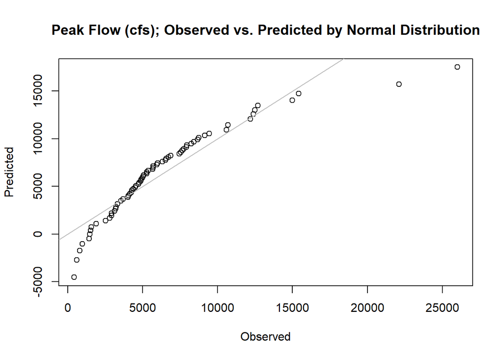

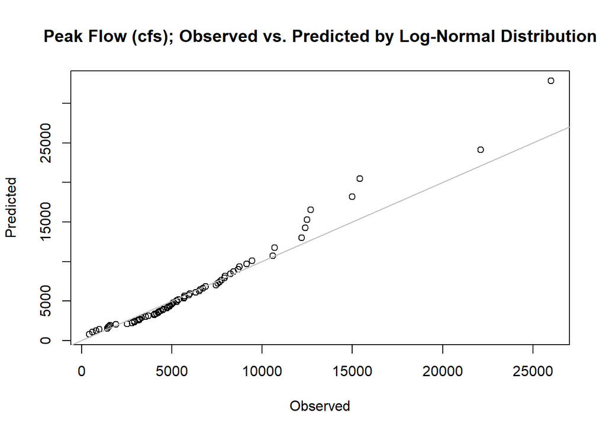

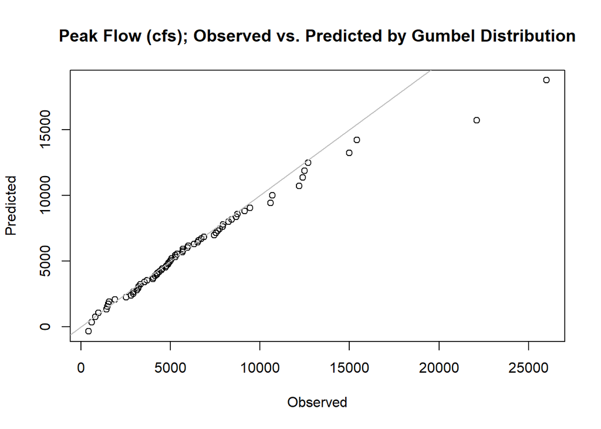

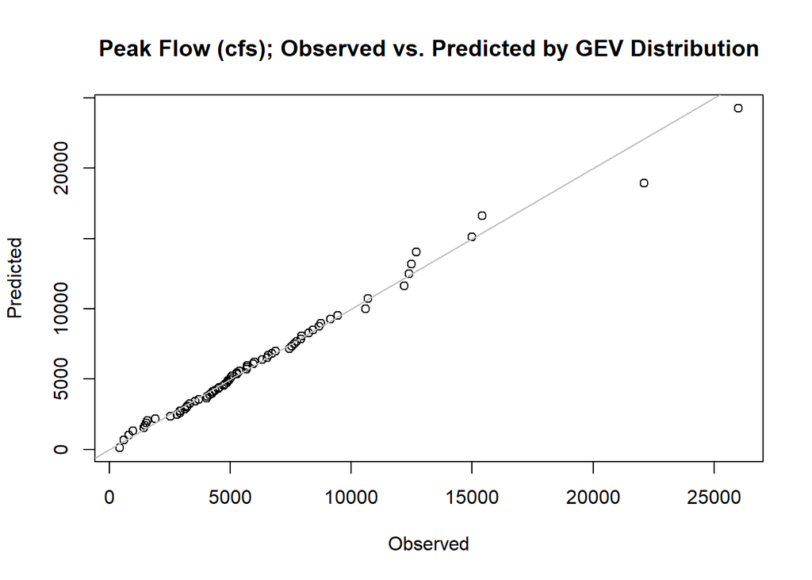

According to the presented plots corresponding to each distribution model, GEV distribution model seems to be better fit to the observed data rather than the other three models. The GEV model has a better fit for late-temporal data as well.

### 10, 50, and 100 Year Floods Discharges

Assuming stationarity, the discharges corresponding to 10, 50 and 100 year floods can be evaluated using distribution models developed before. Return period for any year can be obtained using the following function:

```r
ReturnPeriod <- function(YEAR){
        rp <- 1-1/YEAR
        return(rp)
}
```

The results for all the flood years and different distribution models has been presented in the following table:

Discharges (cfs) for 10, 50, 100 year flood

|  | 10 Year | 50 Year | 100 Year |
| --- | --- | --- | --- |
| Normal | 12308.00 | 15814.21 | 17051.97 |
| Log-normal | 13587.90 | 24657.51 | 30430.49 |
| Gumbel | 11004.84 | 15890.77 | 17956.33 |
| GEV | 12049.49 | 19273.72 | 22812.05 |

### Non-stationary Model

In this part, a non-stationary GEV distribution model has been developed and fitted to the peak flow data assuming a linear temporal variation in

- Location parameter alone
- Location and scale parameters

For this aim, the `location.fun` argument of the `fevd` function should be defined as a linear function of time (year). In stationarity model, all the parameters of GEV model should be constant. The non-stationary GEV model for the peak flow data are shown below:

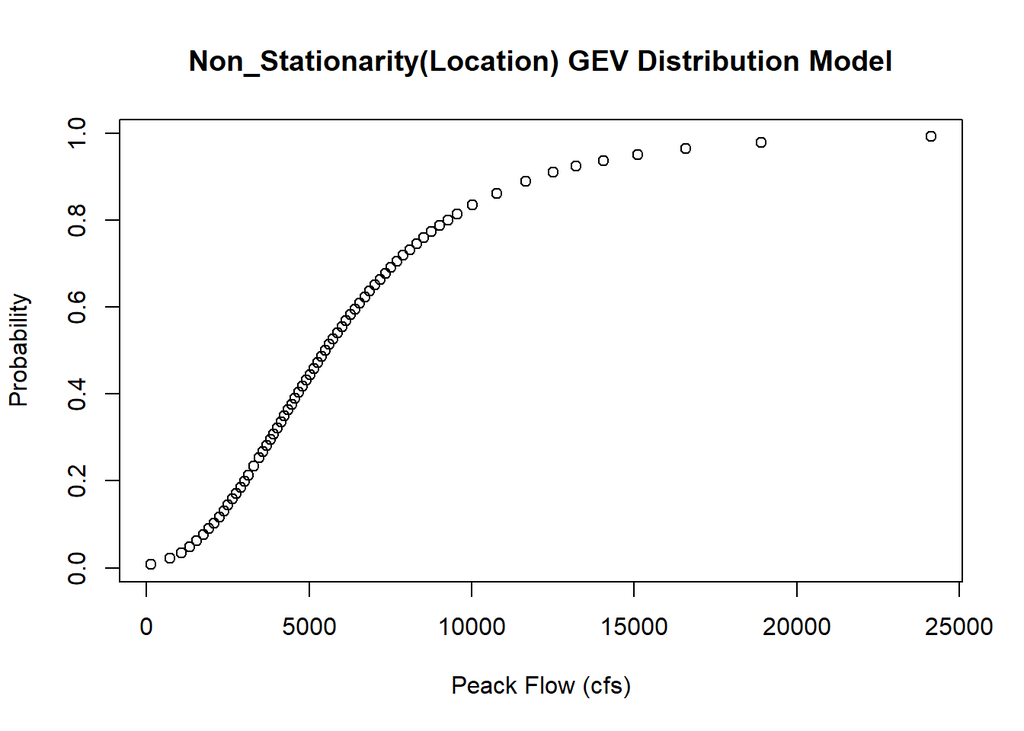

To compare the non-stationary and stationary models, the predicted peak flows for both models were plotted against each other. The plot is shown below:

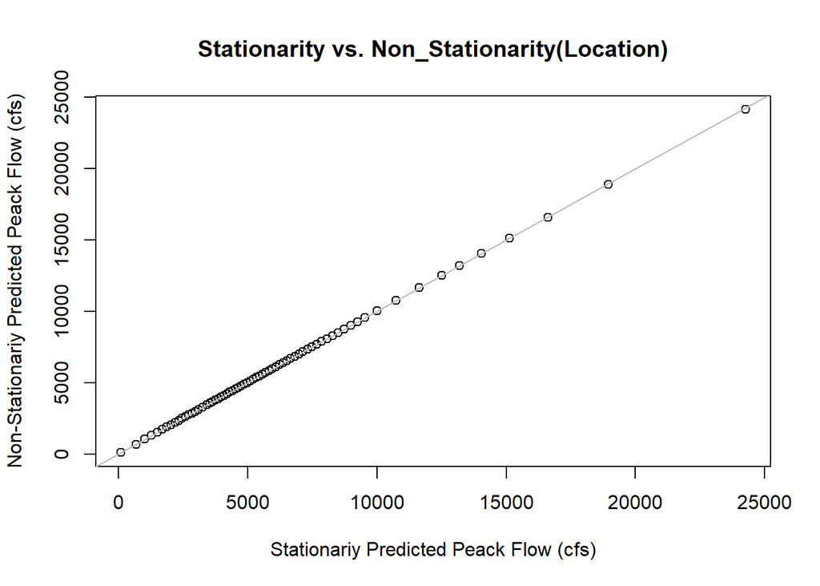

The comparison between non-stationary and stationary GEV models shows similar trend for both. Visually the fit on the 45 degree line which means they are close to each other. However, they have differences which cannot be seen visually.

The model can be developed considering scale parameter of GEV distribution model to be as a function of time as well. The next two plots show the peak flow results of the non-stationarity model when location and scale parameters are a linear terporal functions.

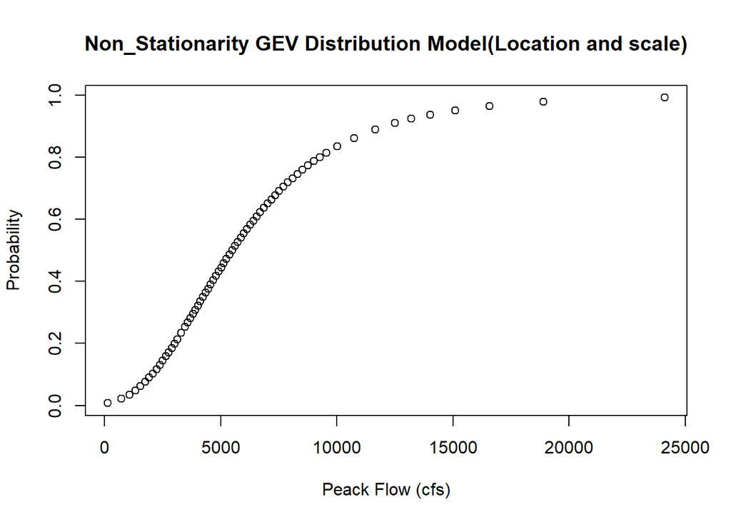

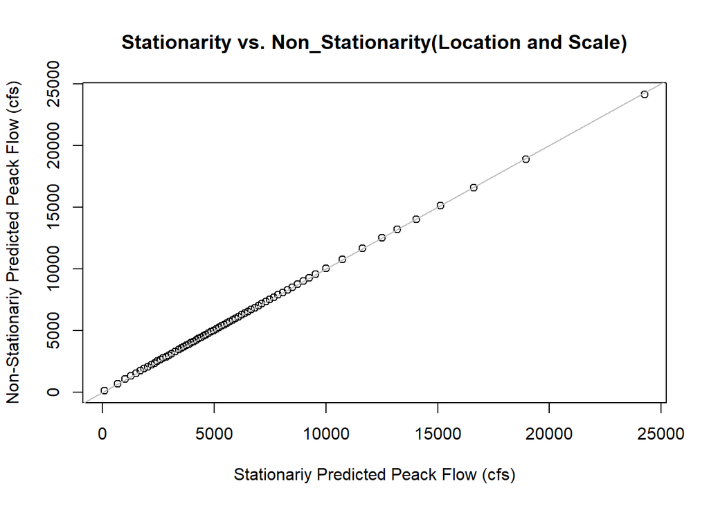

Same as the previous case, the non-stationary GEV model when location and scale parameters are changing by time is also very close to the stationary model. The following plot shows all the GEV models and empirical data:

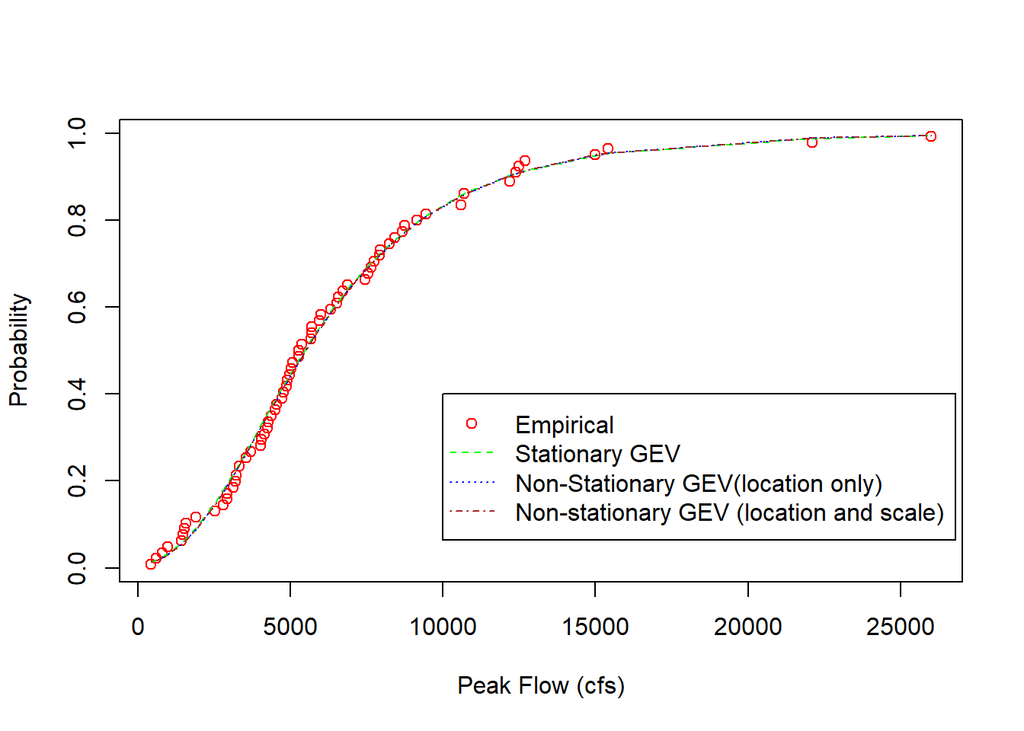

### Flow Duration Curve

Flow curve duration can be used to obtain percentage of time that a particular discharge was equaled or exceeded. To evaluate the exceedance corresponding to the peak annual flood in the year 2011 (the driest single year in the recorded history of Texas), flow curve duration is constructed. Calculation of exceedance is done by applying Gringorten function to the data as following code indicates:

The Flow Duration Curve has been plotted as following:

```r
# Remove zeros form stream-flow data
Streamflow <- Streamflow[ Streamflow != 0 ]

# Calculate exceedance using Gringorten Formula
N <- length(Streamflow) # Number of data
Streamflow_rank <- rank(Streamflow) # rank of data
exceedance <- 1 -(Streamflow_rank-0.44)/(N+0.12) # Gringorten distribution
```

The flow curve duration is shown as follows:

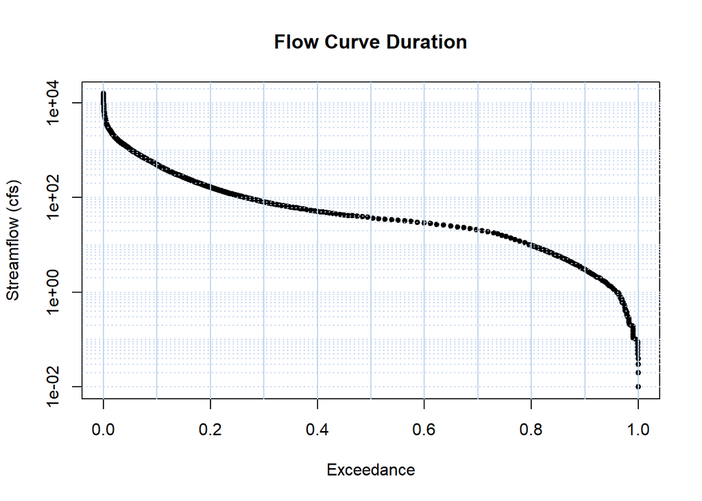

As an example, based on the flow duration curve, the maximum flow rate that is not exceeding 60 % of the time is approximately 20 cfs

The maximum flow that occured in 2011 is 1780 cfs. The corresponding exceedance to this flow is approximately 3 % or based on flow duration curve.

### Annual and Monthly Variation in the Stream-flow

Box-plot can be utlized to depict the intra-annual and intra-monthly variations in stream-flow. Box-plots was annual and monthly stream-flow are shown here:

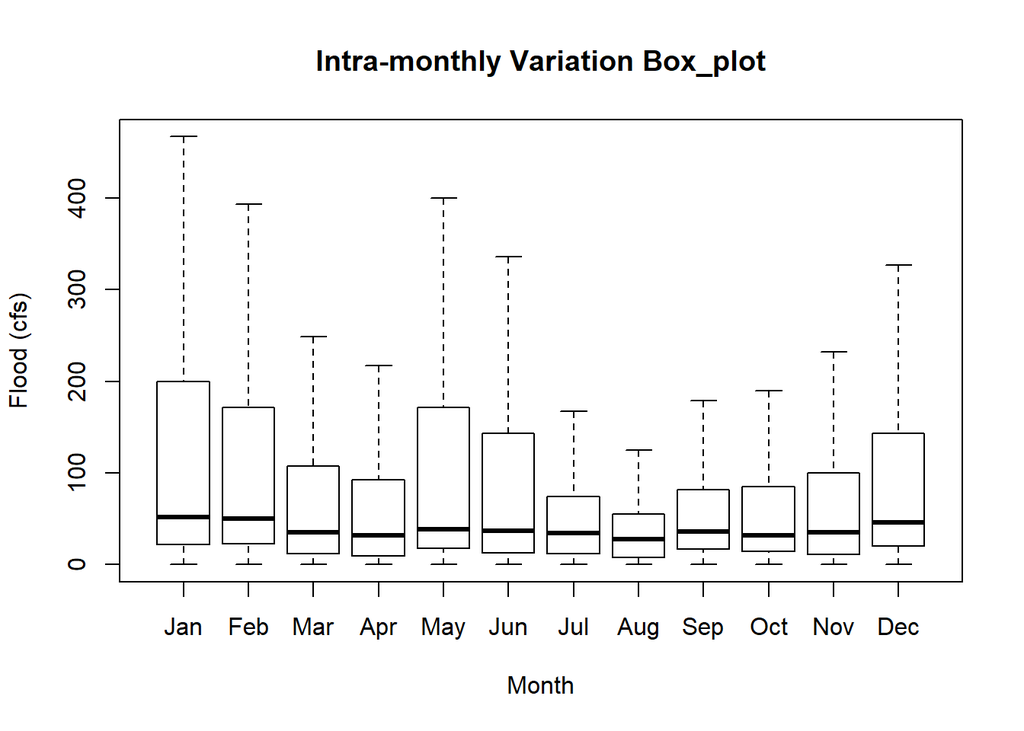

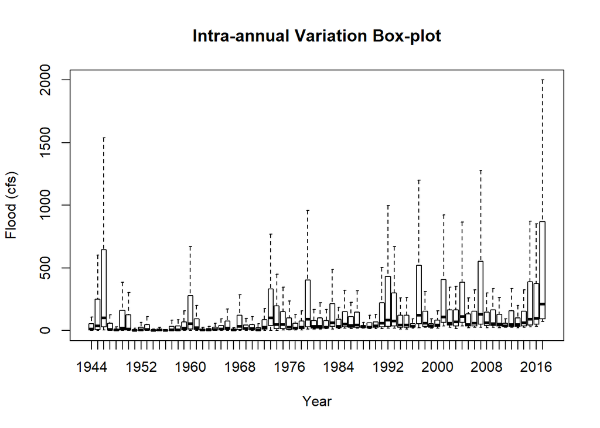

The box-plot for intra monthly variations shows high variability for January. January is in winter, it is possible that some years experience very high flood and on the other hand some years may drought happens, causing high variation in the pick flow data.